# Feature engineering and selection

Choosing the features to use is often the most impactful thing to do in machine learning. We do this by *feature selection* and *feature engineering*.

## Feature selection

Feature selection is choosing *which* features to use in your model training.

One thing we might want to check is to see if any features are redundant and if so, drop them. Consider the titanic dataset:

```python
%matplotlib inline
import matplotlib.pyplot as plt

import pandas as pd

df = pd.read_csv('data/titanic.csv')
df.head()
```

|  | pclass | age | sibsp | parch | fare | male | survived |
| --- | --- | --- | --- | --- | --- | --- | --- |
| 0 | 1 | 29.0000 | 0 | 0 | 211.3375 | False | 1 |
| 1 | 1 | 0.9167 | 1 | 2 | 151.5500 | True | 1 |
| 2 | 1 | 2.0000 | 1 | 2 | 151.5500 | False | 0 |
| 3 | 1 | 30.0000 | 1 | 2 | 151.5500 | True | 0 |
| 4 | 1 | 25.0000 | 1 | 2 | 151.5500 | False | 0 |

Fare and pclass seem likely to be redundant. Let's plot them to check:

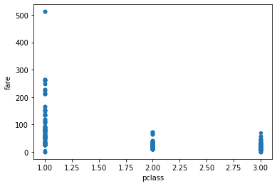

```python
df.plot.scatter('pclass', 'fare')
```

There's definitely some redundancy, though it looks like our first-class passengers had a wide range of fares. Let's compare a decision tree performance with the fare column and without:

```python
from sklearn.tree import DecisionTreeClassifier
from sklearn.metrics import accuracy_score
from sklearn.model_selection import train_test_split

X0 = df.drop(['survived'], axis=1)
X1 = df.drop(['survived', 'fare'], axis=1)
y = df.survived

X0_train, X0_test, X1_train, X1_test, y_train, y_test = train_test_split(X0, X1, y, random_state=1)
```

```python
t0 = DecisionTreeClassifier(max_depth=3)
t0.fit(X0_train, y_train)
accuracy_score(y_test, t0.predict(X0_test))
```

```
0.7938931297709924
```

```python
t1 = DecisionTreeClassifier(max_depth=3)
t1.fit(X1_train, y_train)
accuracy_score(y_test, t1.predict(X1_test))
```

```
0.7938931297709924
```

We actually don't lose any accuracy here, though that's always something to test.

## Feature engineering

Sometimes the features we're given aren't exposed in a way we can use them. Consider some weather data:

(sourced from Fanaee-T, Hadi, and Gama, Joao, Event labeling combining ensemble detectors and background knowledge, Progress in Artificial Intelligence (2013): pp. 1-15, Springer Berlin Heidelberg.)

```python
df = pd.read_csv('https://www.openml.org/data/get_csv/1796712/php6pI1Nq')
df.head()
```

|  | datetime | time | season | holiday | workingday | weather | temp | atemp | humidity | windspeed | count | dayOfWeek |
| --- | --- | --- | --- | --- | --- | --- | --- | --- | --- | --- | --- | --- |
| 0 | '2011-01-01 00:00:00' | '00:00:00' | '1' | '0' | '0' | '1' | 9.84 | 14.395 | 81 | 0.0 | 16 | 'zaterdag' |
| 1 | '2011-01-01 01:00:00' | '01:00:00' | '1' | '0' | '0' | '1' | 9.02 | 13.635 | 80 | 0.0 | 40 | 'zaterdag' |
| 2 | '2011-01-01 02:00:00' | '02:00:00' | '1' | '0' | '0' | '1' | 9.02 | 13.635 | 80 | 0.0 | 32 | 'zaterdag' |
| 3 | '2011-01-01 03:00:00' | '03:00:00' | '1' | '0' | '0' | '1' | 9.84 | 14.395 | 75 | 0.0 | 13 | 'zaterdag' |
| 4 | '2011-01-01 04:00:00' | '04:00:00' | '1' | '0' | '0' | '1' | 9.84 | 14.395 | 75 | 0.0 | 1 | 'zaterdag' |

Can we use the datatime to predict the temperature using a linear model? Not without some work:

```python
df['datetime'] = pd.to_datetime(df['datetime'])
df.head()
```

|  | datetime | time | season | holiday | workingday | weather | temp | atemp | humidity | windspeed | count | dayOfWeek |
| --- | --- | --- | --- | --- | --- | --- | --- | --- | --- | --- | --- | --- |
| 0 | 2011-01-01 00:00:00 | '00:00:00' | '1' | '0' | '0' | '1' | 9.84 | 14.395 | 81 | 0.0 | 16 | 'zaterdag' |
| 1 | 2011-01-01 01:00:00 | '01:00:00' | '1' | '0' | '0' | '1' | 9.02 | 13.635 | 80 | 0.0 | 40 | 'zaterdag' |
| 2 | 2011-01-01 02:00:00 | '02:00:00' | '1' | '0' | '0' | '1' | 9.02 | 13.635 | 80 | 0.0 | 32 | 'zaterdag' |
| 3 | 2011-01-01 03:00:00 | '03:00:00' | '1' | '0' | '0' | '1' | 9.84 | 14.395 | 75 | 0.0 | 13 | 'zaterdag' |
| 4 | 2011-01-01 04:00:00 | '04:00:00' | '1' | '0' | '0' | '1' | 9.84 | 14.395 | 75 | 0.0 | 1 | 'zaterdag' |

Maybe we could use time of day as a feature?

```python
df['hour'] = df.datetime.dt.hour
df.head()
```

|  | datetime | time | season | holiday | workingday | weather | temp | atemp | humidity | windspeed | count | dayOfWeek | hour |
| --- | --- | --- | --- | --- | --- | --- | --- | --- | --- | --- | --- | --- | --- |
| 0 | 2011-01-01 00:00:00 | '00:00:00' | '1' | '0' | '0' | '1' | 9.84 | 14.395 | 81 | 0.0 | 16 | 'zaterdag' | 0 |
| 1 | 2011-01-01 01:00:00 | '01:00:00' | '1' | '0' | '0' | '1' | 9.02 | 13.635 | 80 | 0.0 | 40 | 'zaterdag' | 1 |
| 2 | 2011-01-01 02:00:00 | '02:00:00' | '1' | '0' | '0' | '1' | 9.02 | 13.635 | 80 | 0.0 | 32 | 'zaterdag' | 2 |
| 3 | 2011-01-01 03:00:00 | '03:00:00' | '1' | '0' | '0' | '1' | 9.84 | 14.395 | 75 | 0.0 | 13 | 'zaterdag' | 3 |
| 4 | 2011-01-01 04:00:00 | '04:00:00' | '1' | '0' | '0' | '1' | 9.84 | 14.395 | 75 | 0.0 | 1 | 'zaterdag' | 4 |

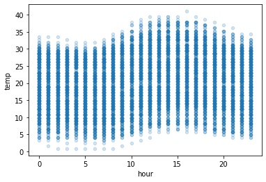

```python
df.plot.scatter('hour', 'temp', alpha=0.2)
```

What about the season?

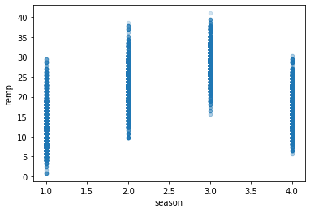

```python
def to_int(season):
    return int(season[1:-1])
df['season'] = df.season.apply(to_int)
df.plot.scatter('season', 'temp', alpha=0.2)
```

```python
from sklearn.linear_model import LinearRegression
from sklearn.metrics import mean_absolute_error

X0 = pd.concat([df.hour, df.season], axis=1)
```

```python
model = LinearRegression()
model.fit(X0, df.temp)
mean_absolute_error(df.temp, model.predict(X0))
```

```
6.414357853350039
```

# Encoding categorical data

Both of these are promising, but they're not linear. We can fix this by one-hot encoding them:

```python
X1 = pd.get_dummies(X0, columns=['hour', 'season'])
X1.head()
```

|  | hour_0 | hour_1 | hour_2 | hour_3 | hour_4 | hour_5 | hour_6 | hour_7 | hour_8 | hour_9 | ... | hour_18 | hour_19 | hour_20 | hour_21 | hour_22 | hour_23 | season_1 | season_2 | season_3 | season_4 |
| --- | --- | --- | --- | --- | --- | --- | --- | --- | --- | --- | --- | --- | --- | --- | --- | --- | --- | --- | --- | --- | --- |
| 0 | 1 | 0 | 0 | 0 | 0 | 0 | 0 | 0 | 0 | 0 | ... | 0 | 0 | 0 | 0 | 0 | 0 | 1 | 0 | 0 | 0 |
| 1 | 0 | 1 | 0 | 0 | 0 | 0 | 0 | 0 | 0 | 0 | ... | 0 | 0 | 0 | 0 | 0 | 0 | 1 | 0 | 0 | 0 |
| 2 | 0 | 0 | 1 | 0 | 0 | 0 | 0 | 0 | 0 | 0 | ... | 0 | 0 | 0 | 0 | 0 | 0 | 1 | 0 | 0 | 0 |
| 3 | 0 | 0 | 0 | 1 | 0 | 0 | 0 | 0 | 0 | 0 | ... | 0 | 0 | 0 | 0 | 0 | 0 | 1 | 0 | 0 | 0 |
| 4 | 0 | 0 | 0 | 0 | 1 | 0 | 0 | 0 | 0 | 0 | ... | 0 | 0 | 0 | 0 | 0 | 0 | 1 | 0 | 0 | 0 |

5 rows × 28 columns

```python
model = LinearRegression()
model.fit(X1, df.temp)
mean_absolute_error(df.temp, model.predict(X1))
```

```
3.4773239460373415
```

# Lab

Open Feature Engineering Lab